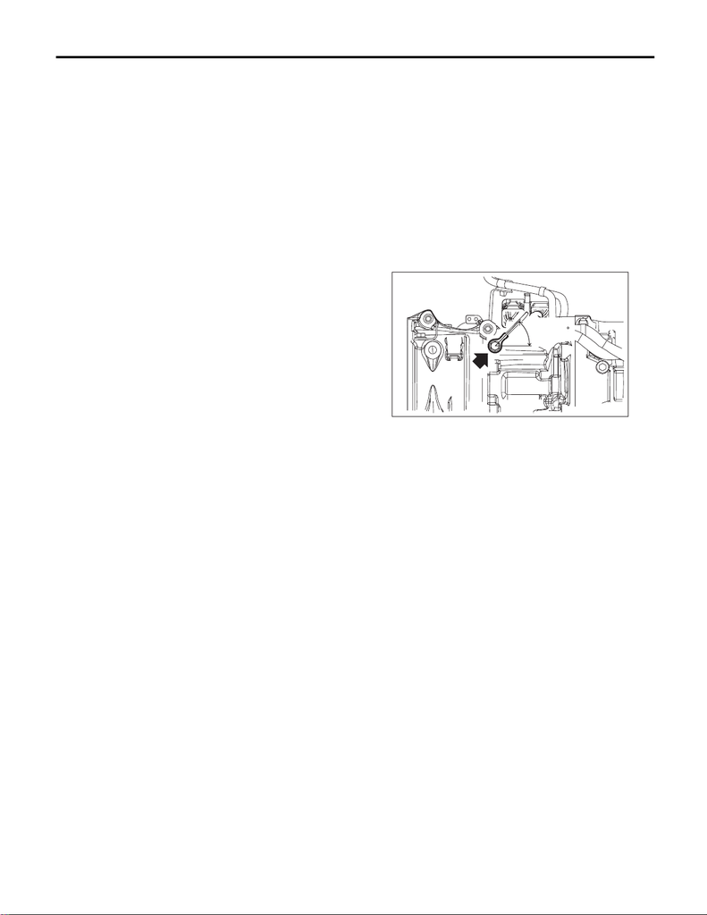

General Description

CONTINUOUSLY VARIABLE TRANSMISSION (DIAGNOSTICS)

3. General Description

A: CAUTION

1) The airbag system wiring harness is routed near

the TCM.

CAUTION:

• All the airbag system wiring harnesses and

connectors are colored yellow. Do not use an

electric test equipment to check these circuits.

• Be careful not to damage the airbag system

wiring harness when performing diagnostics or

servicing the TCM.

2) When measuring the voltage or resistance of in-

dividual sensor or all electrical control modules,

use a tapered pin with a diameter of 0.6 mm (0.024

in) or less and touch it to the tip of terminal. Never

insert the tapered pin into the terminal because it

deforms inside which may lead to malfunction.

CAUTION:

If a pin (or similar) was inserted in TCM connec-

tor, replace the TCM connector.

3) The TCM connector is waterproof. When mea-

suring the TCM connector terminal voltage, or the

resistance between the terminals, use the ST.

ST 18460AA040 CHECK BOARD

B: INSPECTION

1. BATTERY

Measure the battery voltage and specific gravity of

the electrolyte.

Standard voltage: 12 V or more

Specific gravity: 1.260 or more

2. TRANSMISSION GROUND

Make sure that the ground terminal bolt is tightened

securely.

Tightening torque:

16 N·m (1.6 kgf-m, 11.8 ft-lb)

3. OPERATION OF SHIFT SELECT LEVER

Make sure there is no noise, dragging or contact

pattern in each select lever range.

WARNING:

Stop the engine while checking operation of the

select lever.

(Approx. 45 )

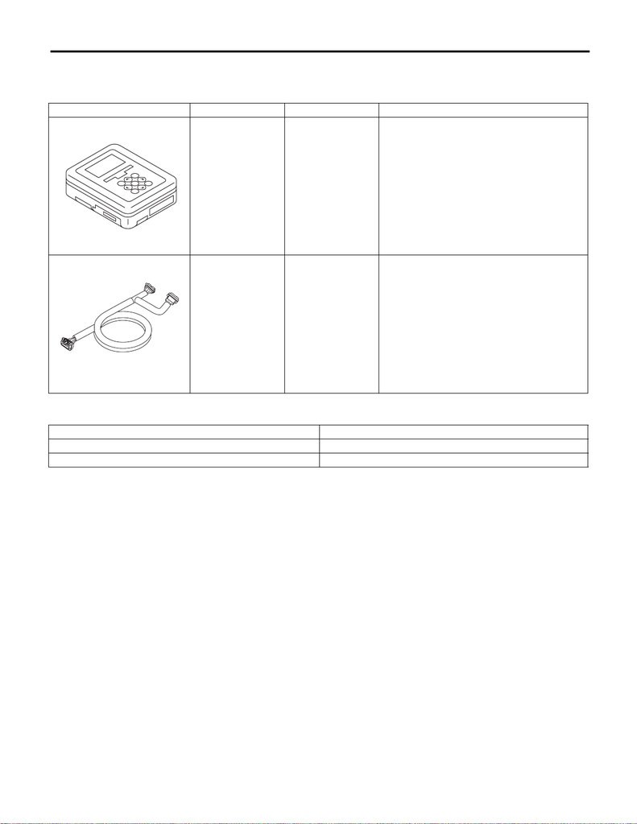

General Description

CONTINUOUSLY VARIABLE TRANSMISSION (DIAGNOSTICS)

C: PREPARATION TOOL

1. SPECIAL TOOL

2. GENERAL TOOL

ILLUSTRATION TOOL NUMBER DESCRIPTION REMARKS

1B022XU0 SUBARU SELECT

MONITOR III KIT

Used for troubleshooting the electrical system.

18460AA040

(Newly adopted tool)

CHECK BOARD Used for measuring the TCM terminal voltage.

TOOL NAME REMARKS

Circuit tester Used for measuring resistance, voltage and current.

Oscilloscope Used for measuring the sensor.

ST1B022XU0

ST18460AA040